# Rockfish Historical Harvest Estimates

Phil Joy & Adam Reimer

February 2025

This project seeks to estimate sport fish harvest and releases of rockfish in Alaska waters by improving on the Howard et al. (2020) methods and expand the time series back to 1977 when the statewide harvest survey (SWHS) was first implemented. This is essentially a Bayesian version of the Howard methods that allows for more appropriate and defensible sharing of information between areas, handles missing data in a more appropriate manor, accurately propagates uncertainty throughout the estimation procedure and replaces the Howard decision tree approach to low sample sizes with a hierarchical model. The methods and results for generating harvest estimates are generally consistent between the Bayesian model and the Howard methods. Harvest estimates are consistent with Howard estimates during contemporary times, but may differ based on more appropriate weighting of SWHS and logbook data, including estimating and correcting bias in the SWHS data.

**Table 1.** Summary of key improvements in reconstructiing sport fish removals of rockfish using the Bayesian model as compared to the Howard et al. (2020) methods.

[output not shown]

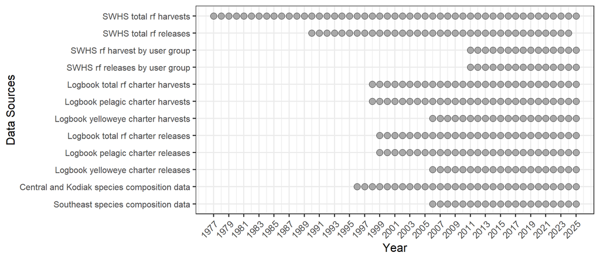

**Figure 1.**- Data sources for estimating rockfish harvests and releases in ADF&G commercial fisheries management units. Note that initial rockfish harvest estimates were not differentiated into species assemblage or species until 1998 when logbooks began differentiating by pelagic and non-pelagic. Logbooks began to collect data on yelloweye beginning in 2006. Port sampling programs to gather data on species composition of harvests began in 1996 in Southcentral and Kodiak and in 2006 in Southeast.

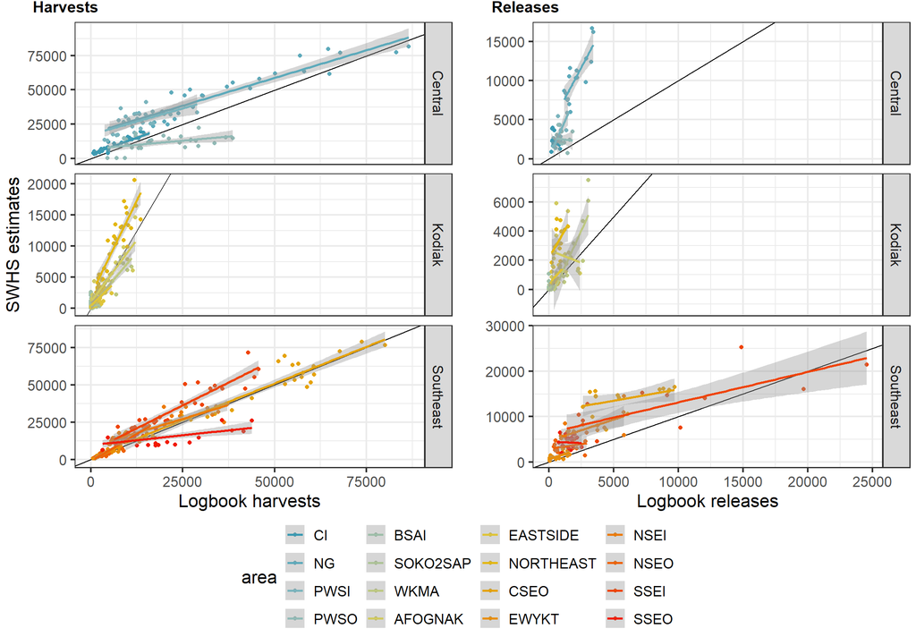

# Results

- **Model:** *LB_fit_3pH*
- **Model Run:** *annual_est_model_kodalt.2_thru2025_1e+05__2026-10-08* (Naming convention: modelname_thruYEAR_iters_rundate)
- **Proportion of parmaters converged (Rhat <= 1.1):** 0.9925
- *See end of document for summary of unconverged parameters.*

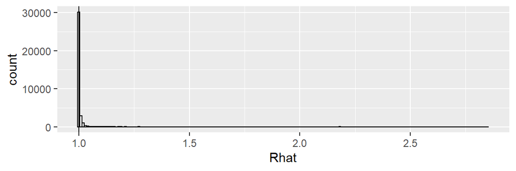

## Estimate comparison

Since previous estimates of rockfish harvest have been produced these first 3 graphs will be used to show how the modeled estimates compare to the estimates produced earlier. For total rockfish the estimates are in general agreement although differences are noted. These estimates should be more reliable because they include both SWHS and guide logbook data, handle variance more appropriately, use hierarchical distributions when data is missing, directly consider observation error and are produced using reproducible research.

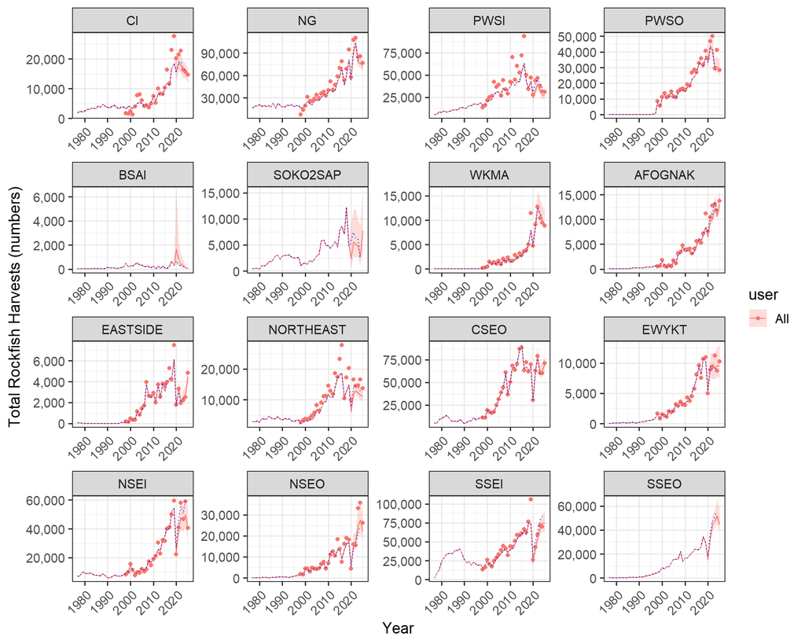

**Figure 3.**- Total rockfish harvests 1996-2023. Lines and error polygons represent model estimates and points and error bars represent Howard et al estimates.

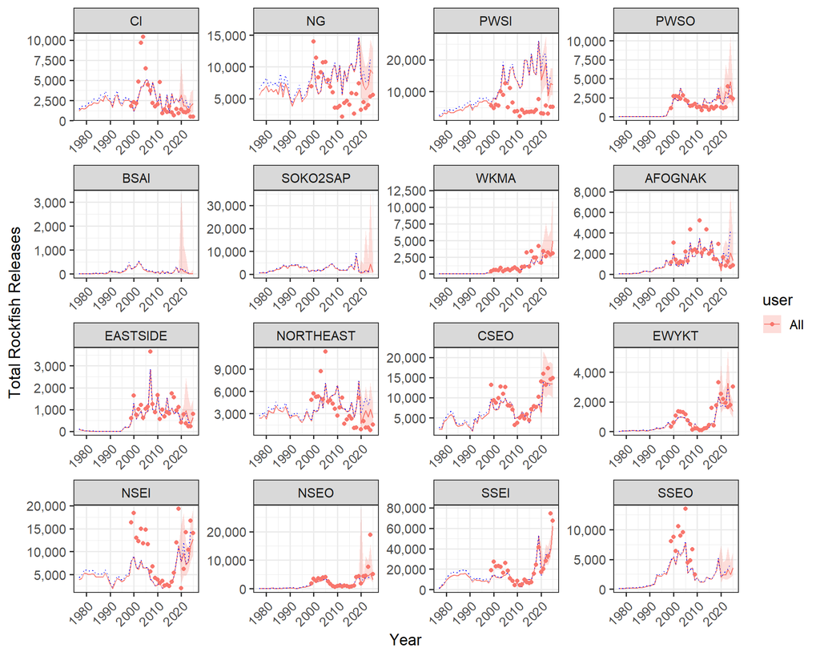

**Figure 3.**- Total rockfish releases 1996–2023. Lines and error polygons represent model estimates and points and error bars represent Howard et al estimates.

*Notes from Adam:* When looking at only black rockfish the most significant differences are for the Prince William Sound Inside area. I did not spend a great deal of time tracking this down although it looks like the previous version used bad values for $P_{(black)ayu}$ for at least unguided anglers. For the moment I would ignore the results for BSIA and SOKO2SAP. I think it is possible to give approximate values for these areas but it will require a little more coding which I have yet to do.

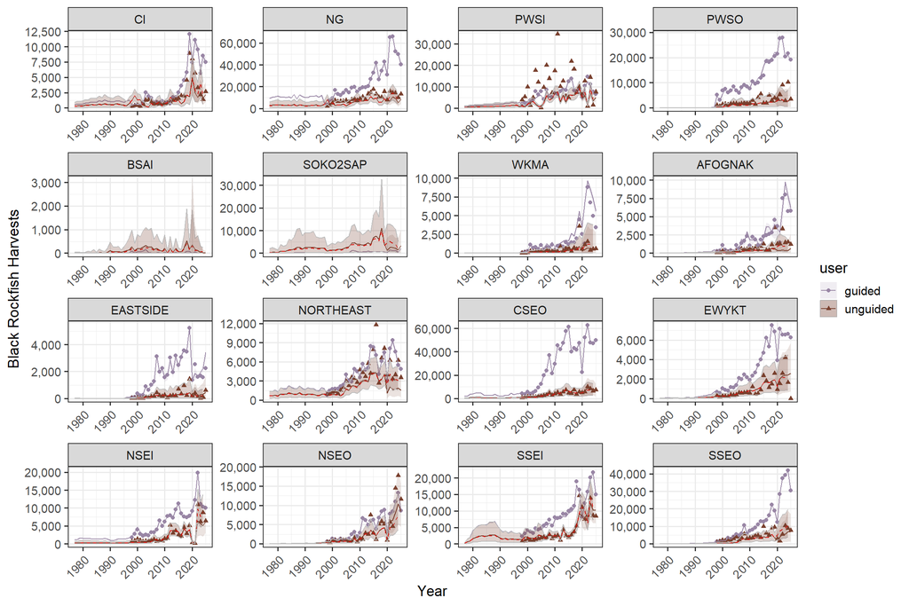

**Figure 4.**- Black rockfish harvests 1996–2023. Lines and error polygons represent model estimates and points and error bars represent Howard et al estimates.

And black rockfish releases…

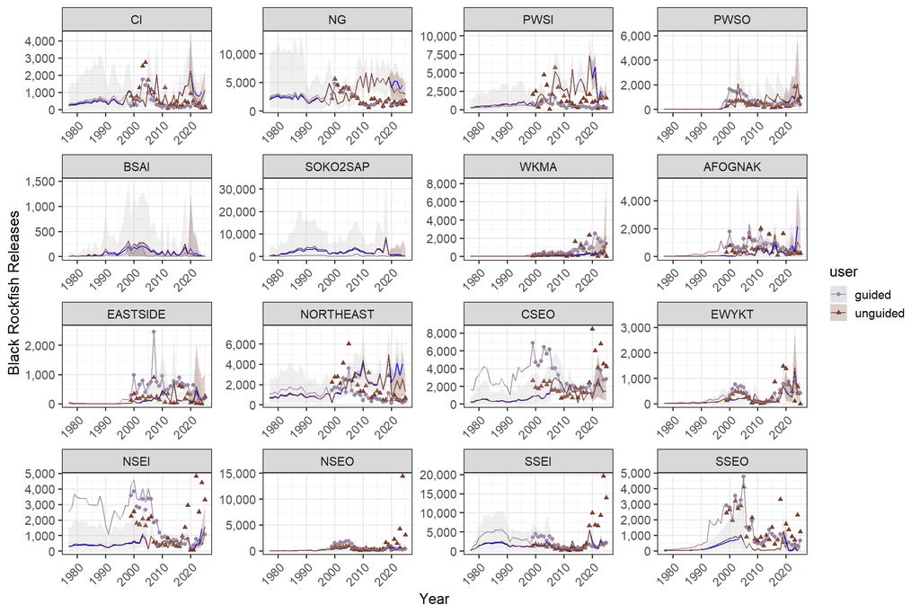

**Figure 5.**- Black rockfish releases 1996–2023. Lines and error polygons represent model estimates and points and error bars represent Howard et al estimates.

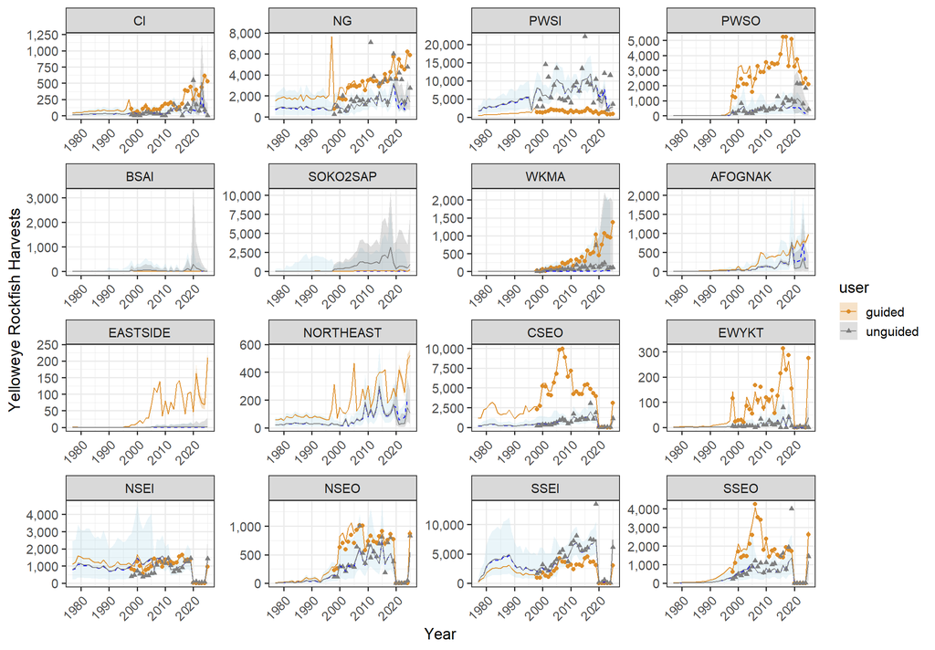

**Figure 6.**- Yellow rockfish harvests 1996–2023. Lines and error polygons represent model estimates and points and error bars represent Howard et al estimates.

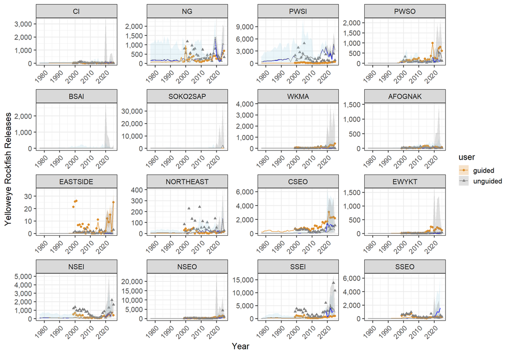

**Figure 7.**- Yellow rockfish releases 1996–2023. Lines and error polygons represent model estimates and points and error bars represent Howard et al estimates.

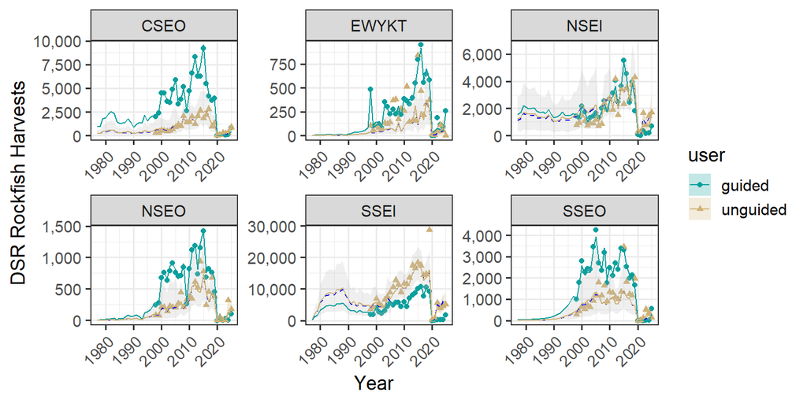

**Figure 8.**- DSR rockfish (excluding yelloweye) harvests 1996–2023. Lines and error polygons represent model estimates and points and error bars represent Howard et al estimates.

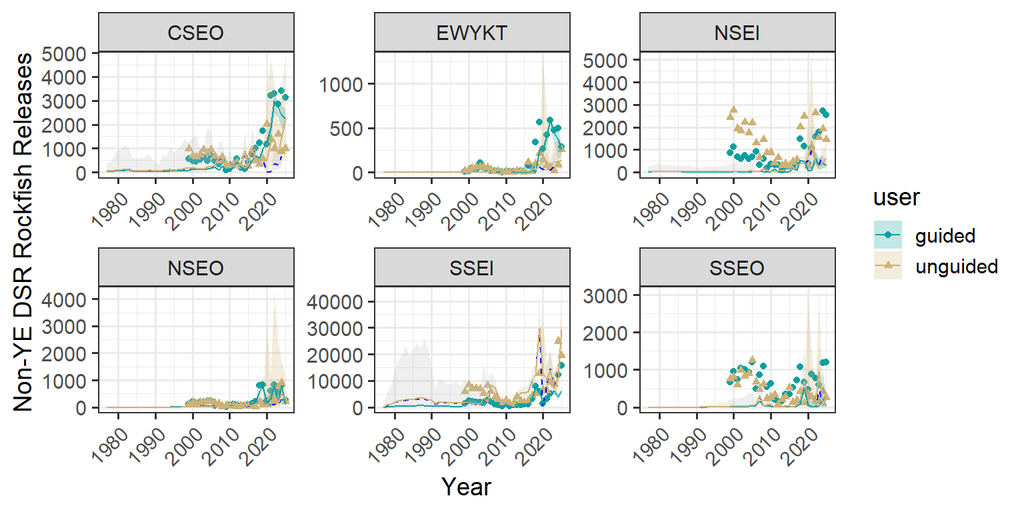

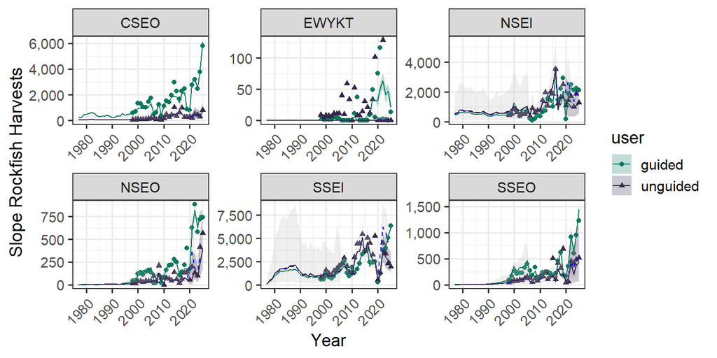

**Figure 11.**- Slope rockfish harvests 1996-2023. Lines and error polygons represent model estimates and points and error bars represent Howard et al estimates.

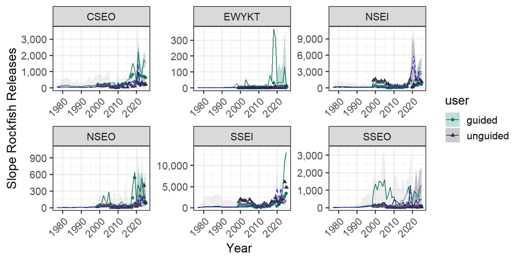

**Figure 12.**- Slope rockfish releases 1996–2023. Lines and error polygons represent model estimates and points and error bars represent Howard et al estimates.

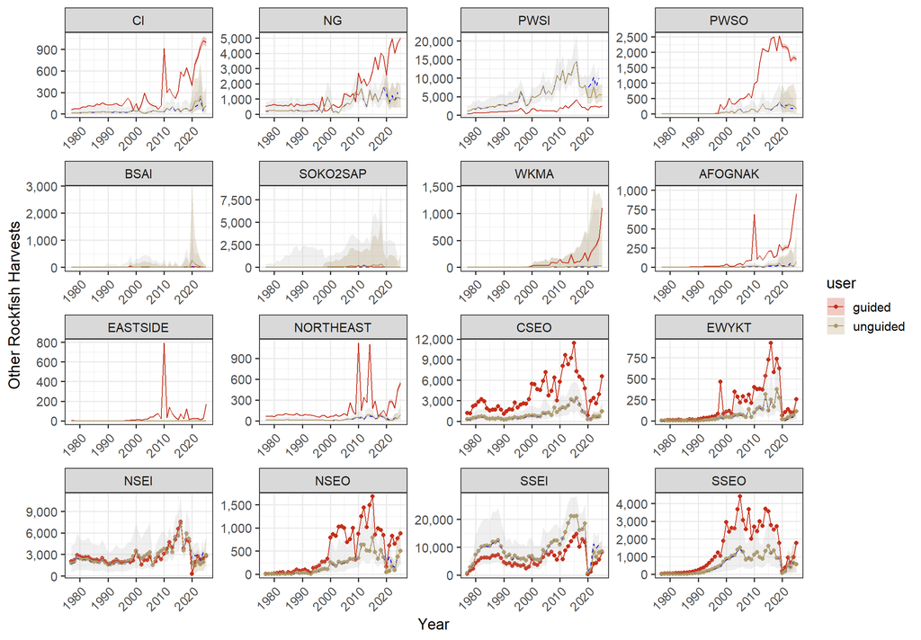

**Figure 13.**- *Other* rockfish (non-pelagic and non-yelloweye) harvests 1996–2023. Lines and error polygons represent model estimates and points and error bars represent Howard et al estimates.

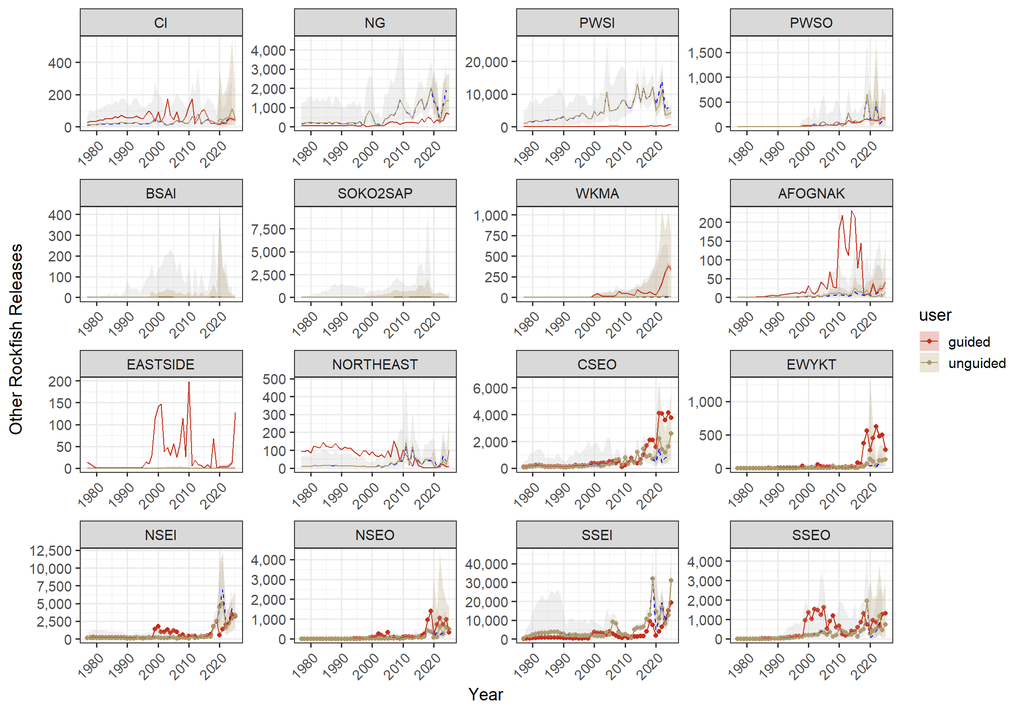

**Figure 14.**- *Other* rockfish (non-pelagic and non-yelloweye) releases 1996–2023. Lines and error polygons represent model estimates and points and error bars represent Howard et al estimates.

## Total Biomass Removal Estimates

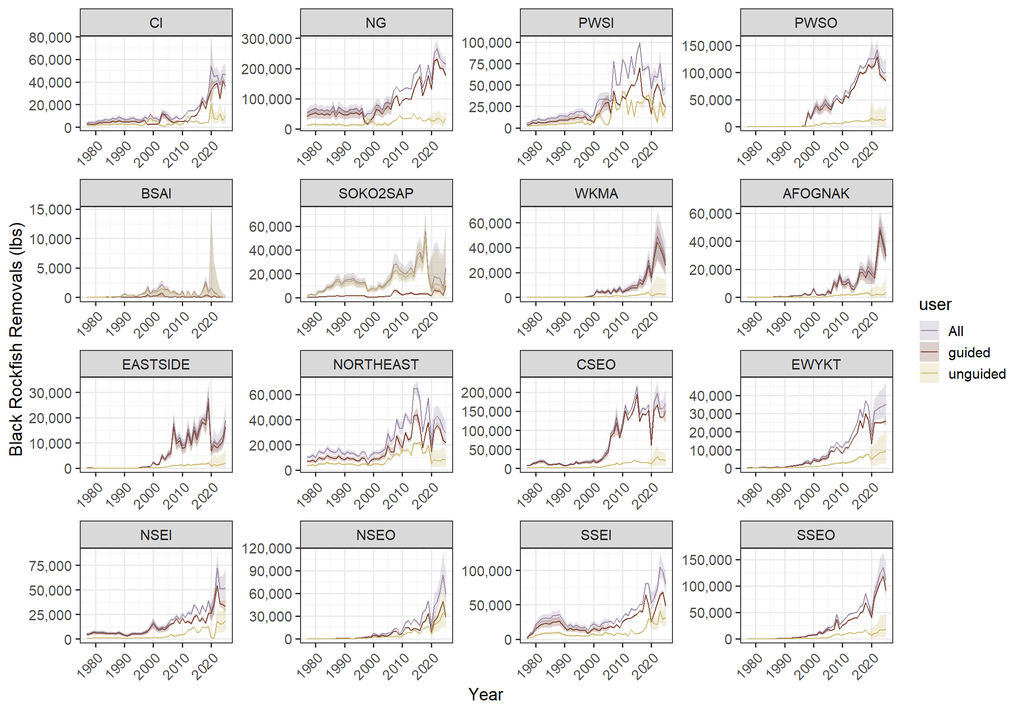

**Figure 15.**- Black rockfish estimated total removals in lbs in 1996–2023. Total removals are calculated from the harvests, the estimated release mortality and mean fish weights. Error polygons represent 95% confidence intervals.

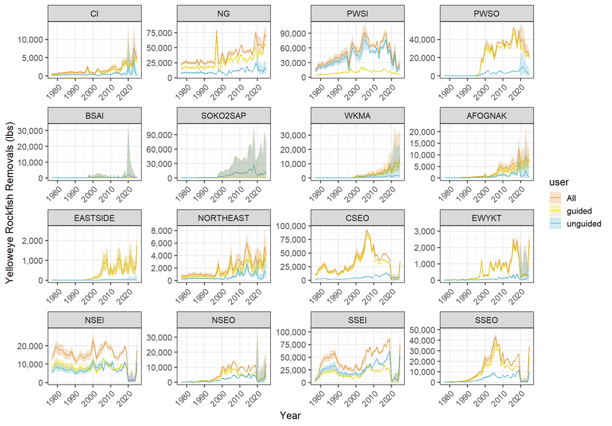

**Figure 16.**- Yellow rockfish estimated total removals in lbs in 1996–2023. Total removals are calculated from the harvests, the estimated release mortality and mean fish weights. Error polygons represent 95% confidence intervals.

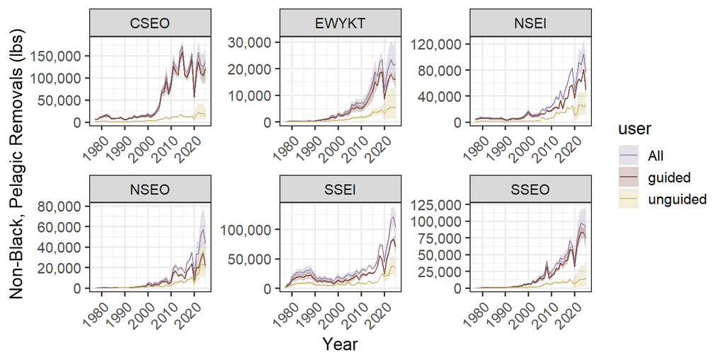

**Figure 17.**- Pelagic rockfish estimated total removals in lbs in 1996–2023. Total removals are calculated from the harvests, the estimated release mortality and mean fish weights. Error polygons represent 95% confidence intervals.

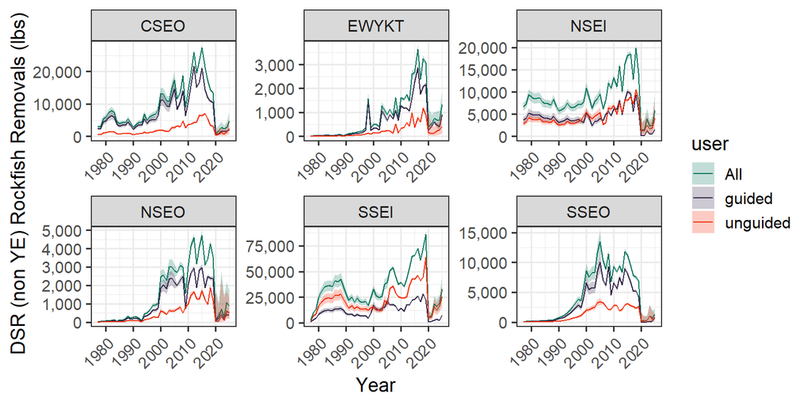

**Figure 18.**- Non-yelloweye, demersal shelf rockfish estimated total removals in lbs in 1996-2023. Total removals are calculated from the harvests, the estimated release mortality and mean fish weights. Error polygons represent 95% confidence intervals.

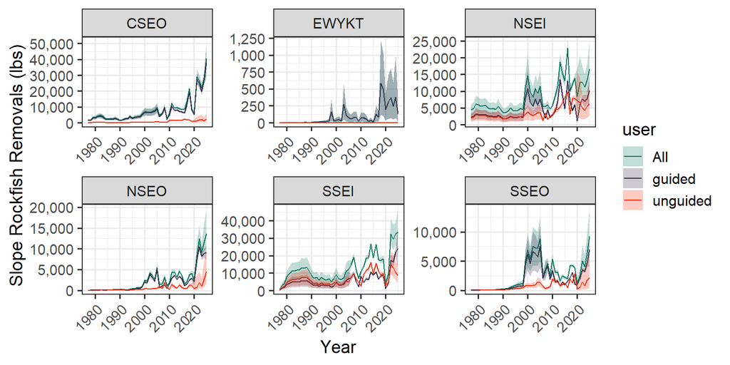

**Figure 19.**- Slope rockfish estimated total removals in lbs in 1996-2023. Total removals are calculated from the harvests, the estimated release mortality and mean fish weights. Error polygons represent 95% confidence intervals.

## Model fit

### Logbook residuals

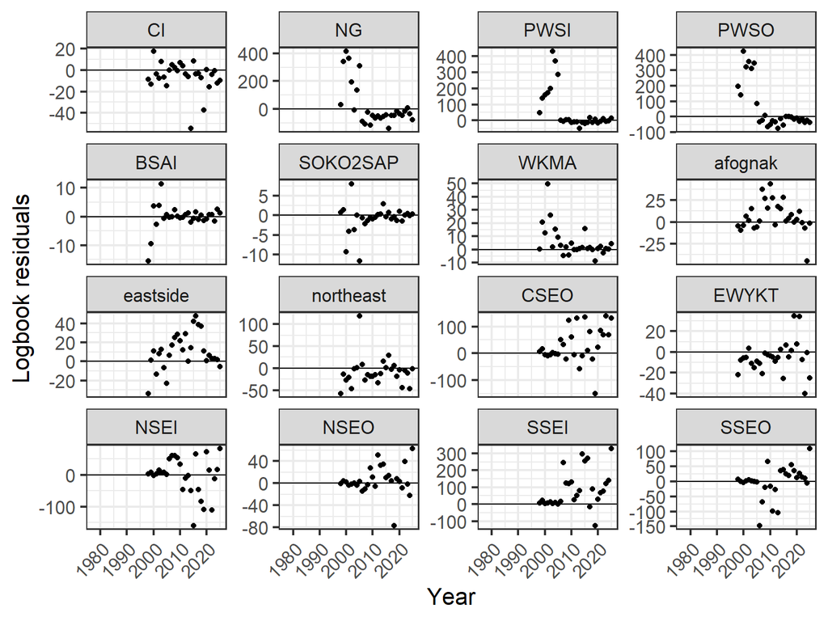

**Figure 20.**- Residuals from logbook harvests.

### SWHS residuals

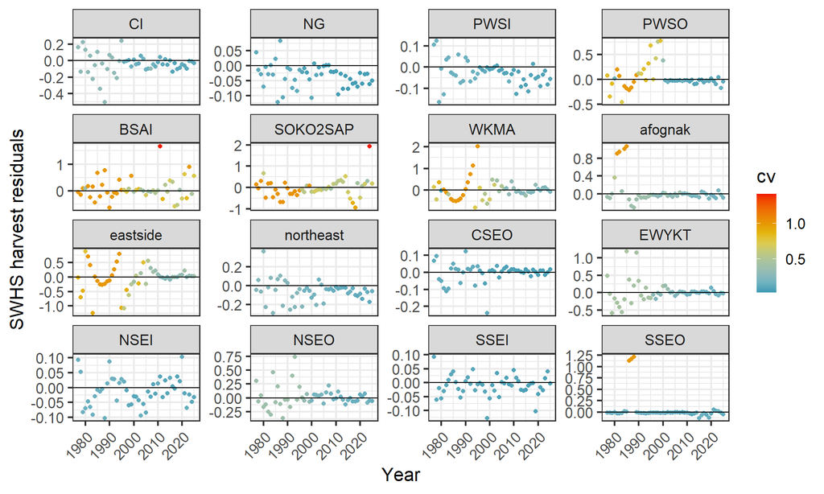

**Figure 21.**- Residuals from SWHS harvests.

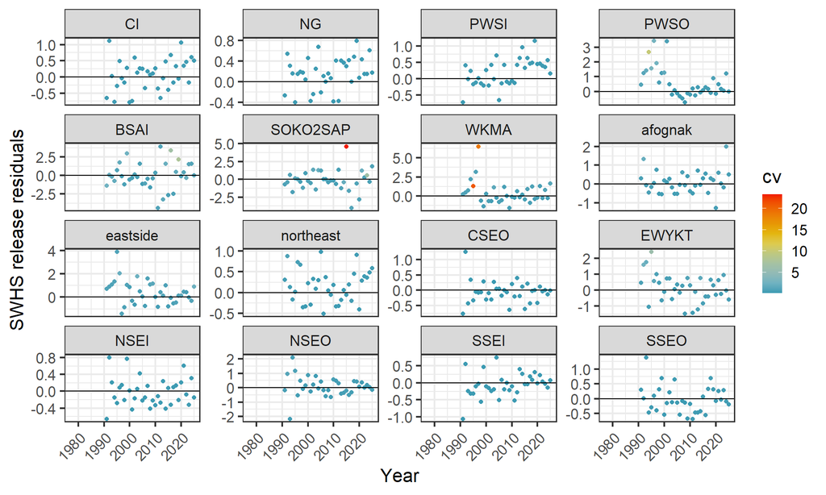

**Figure 22.**- Residual of SWHS releases.

## Parameter estimates

### P(Charter)

These histograms show the posterior distribution of the mean percent of rockfish harvested by the charter fleet.

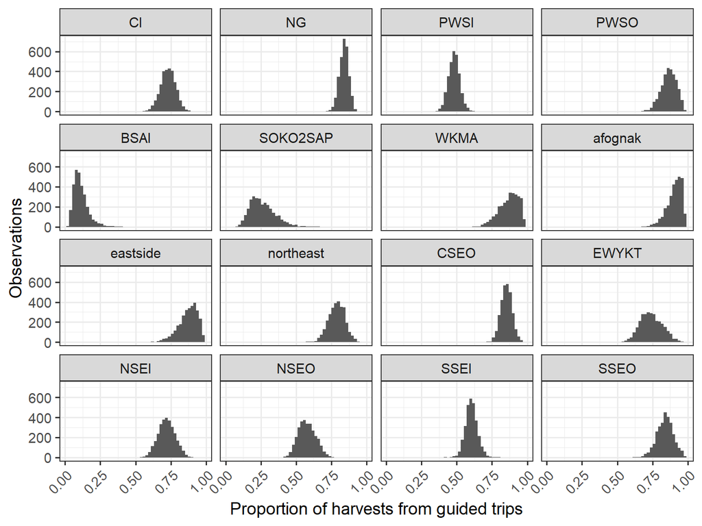

**Figure 23.**- Mean percent of harvest by charter anglers.

When considered annually we see the percent of rockfish harvested by the charter fleet follows our data fairly well although the model smooths out the changes and we just do not have much information about this ratio. Prior to 2011 the percent charter is confounded with SWHS bias and should be mostly discounted.

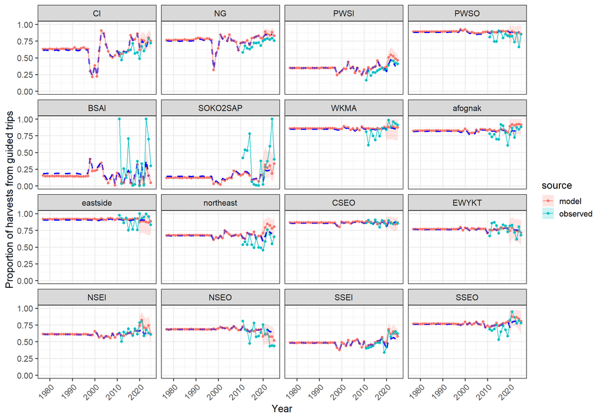

**Figure 24.**- Annual estimates of the percent of harvest by charter anglers for 16 commerical fishing manamgent areas, 1996-2023.

### P(Harvest)

These plots show the fitted logistic line to the proportion of caught rockfish that are harvested. These estimates are used for hindcasting catch estimates based on the harvest data in early years when catch estimates are unavailable.

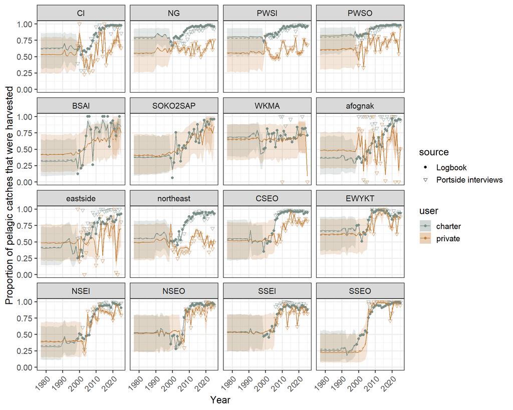

**Figure 25.**- Annual proportion of pelagic rockfish catch that was harvested. Note that pre-1990 estimates are used to estimate catch in these years when catch estimates are not available.

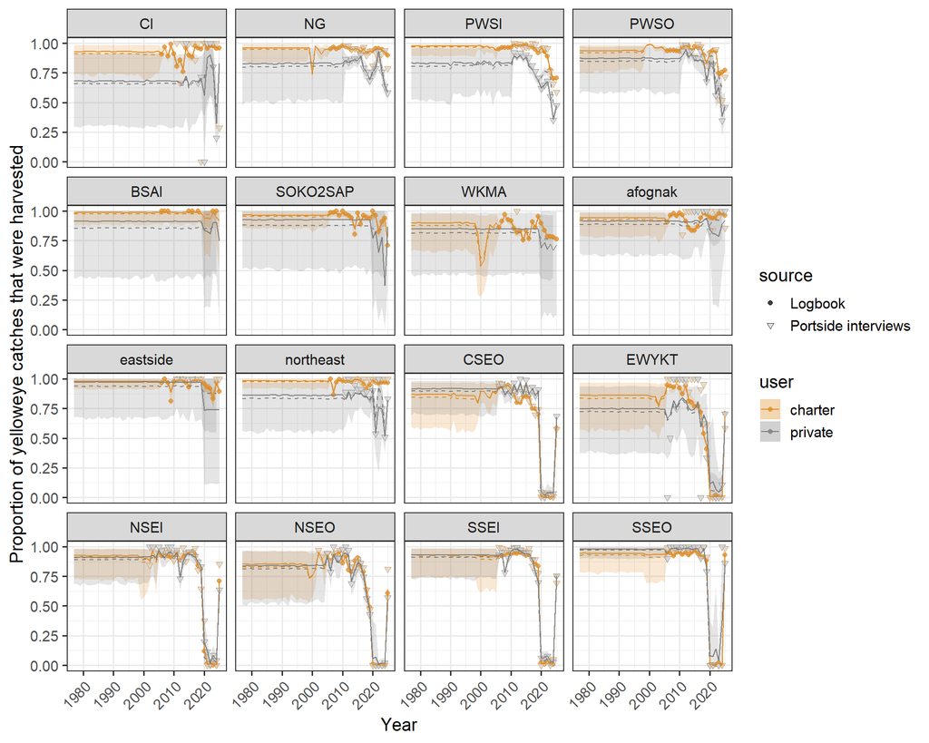

**Figure 26.**- Annual proportion of yelloweye rockfish catch that was harvested. Note that pre-1990 estimates are used to estimate catch in these years when catch estimates are not available.

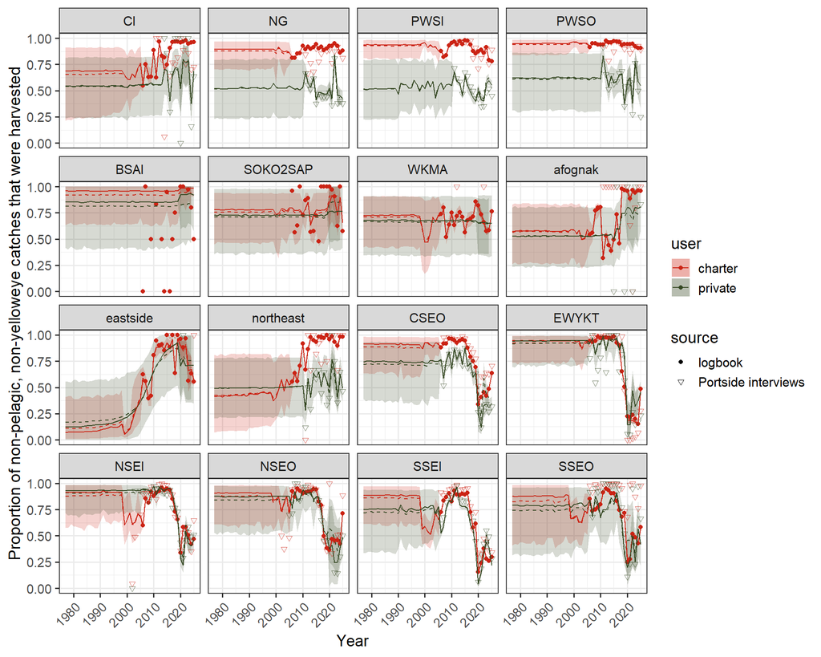

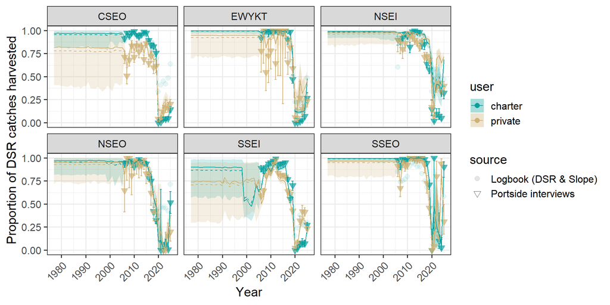

**Figure 28.**- Annual proportion of DSR rockfish catch that was harvested. Note that pre-1990 estimates are used to estimate catch in these years when catch estimates are not available. Note that the observed logbook data is for all non-pelagic, non-yelloweye fish.

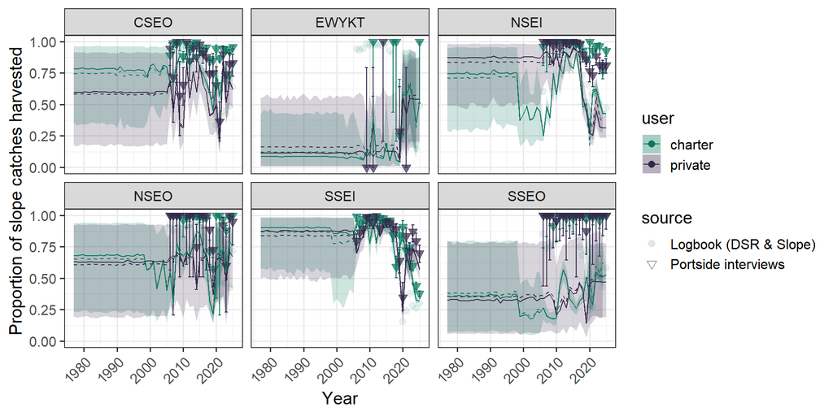

**Figure 29.**- Annual proportion of Slope rockfish catch that was harvested. Note that pre-1990 estimates are used to estimate catch in these years when catch estimates are not available. Note that the observed logbook data is for all non-pelagic, non-yelloweye fish.

### SWHS bias

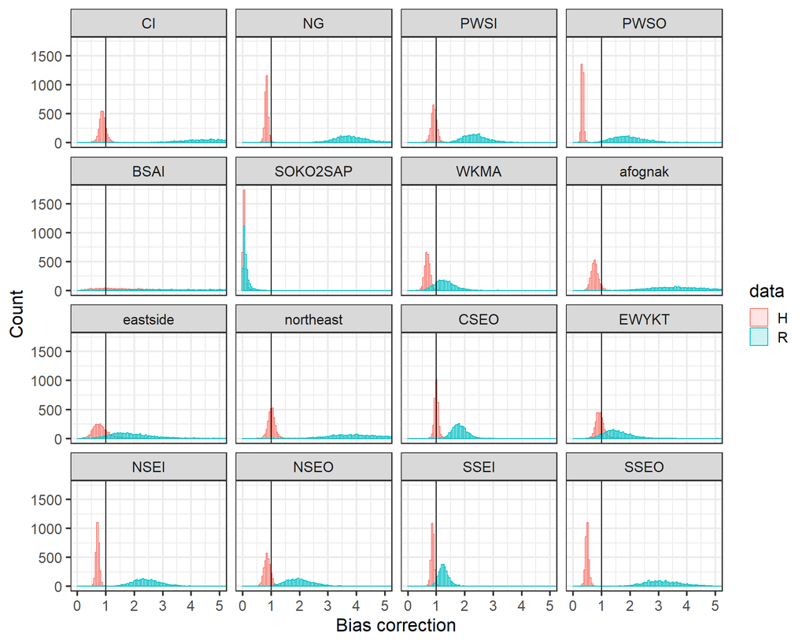

**Figure 30.**- Mean SWHS bias for harvests and catches. Note that a bias < 1 indicates that the SWHS *underestimates* the true value and bias > 1 indicates the survey *overestimates* the true value.

Our estimates of SWHS harvest bias track observations fairly well when he have guided harvest estimates. The estimates of release bias in the SWHS data track observed patterns to an extent, but appear to smooth these more volatile disagreements with the logbook data. Adam postulated in his initial start on this that some of this could be the result of the estimates of the proportion guided. This value was not modelled with a trend and thus applies a constant estimate when hindcasting. Data on these relationships could greatly improve this model.

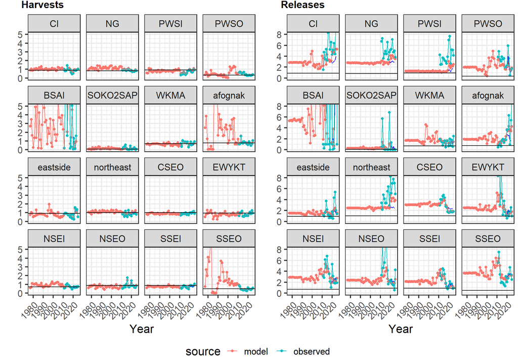

**Figure 31.**- Annual estimates of SWHS bias in harvests and releases for 16 commerical fishing manamgent areas, 1996-2023. Note that a bias < 1 indicates that the SWHS *underestimates* the true value and bias > 1 indicates the survey *overestimates* the true value.